Title: Dharsy D. Rodriguez Velazquez Date: 2023-10-17 Slug: dharsy Category: People Tags: bioinformatics

# Dharsy D. Rodriguez Velazquez

## Contact info:

e-mail

- dharsy.rodriguez@upr.edu

LinkedIn

- www.linkedin.com/in/dharsy-rodriguez

## Bio

Social Sciences student-researcher at Computer Sciences Department. IDGeNe student program at the University of Puerto Rico, Rio Piedras Campus. During the time I will be working with my peers and the Profesor in Bioinformatic of gene expression.

## Research Goals

To combine social sciences, public health (Gentics Epidemiology) with cutting-edge biological research.

## Research Abstract

During the expression of genes in tissues there is cell heterogeneity which causes a massive amount of voluminous information about the normal cells and anomalous cells. Bioinformatics is a field that can provide tools to analyze large data sets. In bioinformatics, computer technology is the main protagonist, it helps to analyze and translate biological data. Hence, we will be using this field to evaluate the differential expression in cancer tissues of humans, using publicly available datasets. We selected samples of homo sapiens colon colorectal tumor core, and adjacent non-malignant colon tissue to study. Our goal is to identify gene patterns, with this in mind the method that will be used to process the data is Binarization, especially the Binary Differential Analysis (BDA). The Binary Differential Analysis has the advantage of reproducibility of data, it reduces the amount of information and detects biologically relevant genes. BDA collects the genes that were expressed as a non-zero value which was assigned a one, if the gene did not express it will be a zero value.

1. Gerard A. Bouland, Ahmed Mahfouz, Marcel J.T. Reinders. The rise of sparser single-cell RNAseq datasets; consequences and opportunities. BioRxiv 2022.05.20.492823; doi: https://doi.org/10.1101/2022.05.20.492823
2. Satija, R., Farrell, J.A., Gennert, D., Schier, A.F. and Regev, A. (2015) Spatial reconstruction of single-cell gene expression data. Nat. Biotechnol. Retrieved from: https://doi.org/10.1038/n bt.3192
3. He D, Zakeri M, Sarkar H, Soneson C, Srivastava A, Patro R. (2022) Alevin-fry unlocks rapid, accurate and memory-frugal quantification of single-cell RNA-seq data. Nat Methods. Mar;19(3):316-322. doi: 10.1038/s41592-022-01408-3. Epub 2022 Mar 11. PMID: 35277707; PMCID: PMC8933848.

## Weekly UPDATES

June 5-9, 2023 -IDGeNe first meeting -Meet & Greet All Summer Programs -Workshop: Mindsets -Workshop: Lab Etiquette and Lab Safety -Workshop: Bioinformatics I and II -Workshop: Software Carpentry -Workshop: Sexual Harrasment -Mentoring: Dr. Adriana Baez –Mentor-Mentee_Align_Expectations (WORD) -Laboratory Work: We prepared a work plan for the summer: – Cancer data – Binarization – Single cell information – Request account for Boqueron cluster – We discussed the rules of the laboratoy:MegaProbe

June 12-16, 2023 -Created Github, Anaconda account -Workshop: Bioinformatic III -Educational Talk: Genomics and Society (Dr. Gerardo Arroyo: La Genómica y su impacto en las Ciencias Forenses) -Meet the Mentors Dr. Tugrul Giray -Workshop: Software Carpentry -Educationall Talk: Impostor Syndrome -Workshop: Software Carpentry -Genomic Seminar:Evolution and development of patterns in butterfly wings -Workshop:Ethics -Movie Night: Justice, Equity, Diversity and Inclusion -Educational Talk: Implicit Bias -Techniques and Journal Club- T. Giray -Deliverable: One Page Research Summary

June 19-24, 2023 -Educational Talk: Genomics and Society Dr. A. Santiago-Cornier Genomic Medicine -Meet the Mentors Dr. Jose Rodríguez Martínez -Laboratory work: Read articles: –Why Binarize? – Data and Software –Cancer Data -Table data of colorectal cancer paper: [2023-06-19 Mon 13:07] Cancer data for scRNAseq –Workshop: IDP -Techniques: Rodriguez-Martinez -Movie Night: Human Nature -Workshop: Science Communication Dr. Kevin Alicea -Journal club: Rodriguez-Martinez -Workshop: Replicathon

June 26-30, 2023 -Laboratory Work: TCGA atlas, GRCh38, review Genetics concepts,GEO data, Array Express data, normal tissue and tumour core, R1_R2_Index, WingSCP, pipeline.

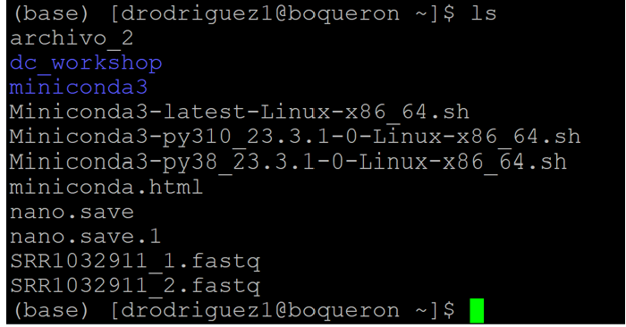

boq 1

-Meet the Mentors: Dr. Imilce Rodríguez Hernández -Techniques Rodríguez-Hernández -Workshop: Grant Funding:(P Ordoñez) -Movie Night: Code Bias -Journal Club: Rodríguez-Hernández -Workshop: How to write a personal statement (P Ordoñez)

July 3-8, 2023

-Laboratory: Boqueron and Hulk, we had an error: We did not tell Hulk to save the fastqc, therefore we fix it. Saving it in nano align. Also we were confused because we had fastq and fastqc mix (L1 andL2) we moved it to anotoher folder. We had an error running piscem, we were trying to write on home, it was not running on the q screen. New Excel and EMTAB. We identify the new samples of the individuals.

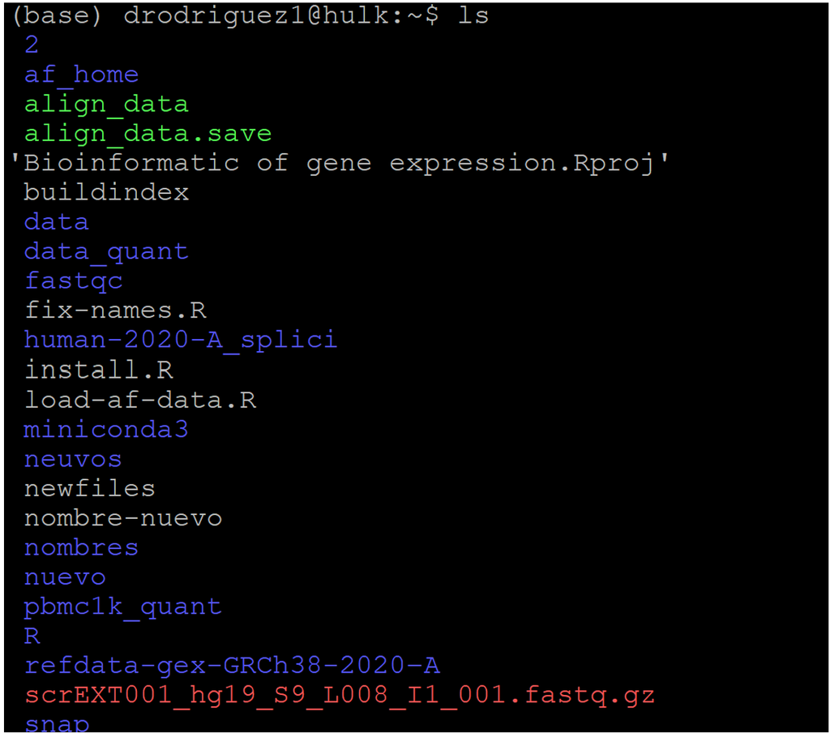

hulk 1

-Meet the Mentors: Carmen Cadilla -Techniques: Carmen Cadilla -Lunch with Dr. Esther Peterson -Deliverable: First Draft Personal Statemen+IDP -Journal Club: Carmen Cadilla -IQ Hackathon (Engine 4)

July 10-14 -Laboratory: Hulk account to work on Rsudio local, Alevin Fry Data (Rscript install), Seurat objetcts tutorial, find the diffrence between normal and tissue core. Download URLs list to match the new table of samples with the columns, identify using rows. Created new directory, we installed miniconda in Hulk.

[figure not shown]

boq 2

-Meet the Mentors: Dr. Alfredo Ghezzi -Galaxy Workshop “Genomics” -Genomics and Society Dr. Joseph Vogel Bounded Openness over Natural Information -Galaxy Workshop “Transcriptomics” -Galaxy Workshop “Metagenomics” - Journal Club:Dr. Alfredo Ghezzi

July 17-21, 2023 -Meet the Mentors Dr. Josue Pérez Santiago -Worskhop: How to prepare an abstract (J García-Arrarás) -Techniques Dr. Josue Pérez Santiago -Workshop: Statistics in Biology (ME Pérez-Hernández) -Journal Club: Josue Pérez Santiago -Deliverable: Updated Research Summary (w/ Lit review + Methods)